# Genomic Ranges workshop

Bin He

4/11/2020

This workshop is self-sufficient, meaning that you can download or copy and paste the entire R markdown file and open it in an RStudio wherever you have it.

## A more realistic application

This tutorial is entirely based on [Genomic Ranges: An Introduction to Working with Genomic Data](https://blog.dominodatalab.com/genomic-ranges-an-introduction-to-working-with-genomic-data/)

### Representing the Genome with a Coordinate System

The human genome is comprised of roughly 3 billion base pairs organized linearly on 23 pairs of chromosomes. Thus, an intuitive way to represent our genome is to use a coordinate system: “chromosome id” and “position along chromosome”. An annotation like chr1:129-131 would represent the 129th to the 131st base pair on chromosome 1.

Let us load GenomicRanges and create an example object to represent some genomic fragments:

```r
## Installation
## we assume that GenomicRanges has been installed

## The code below is how to create the an example GRanges object. The code entered here will create 8 segments on either chr1 or chr2, each with defined start and end points.
## Each read will also have strand information, indicating which direction the sequence is in. seglengths informs us the maximum length of chr1 and chr2.

example = GRanges(seqnames=c(rep("chr1", 4), rep("chr2", 4)),
                  ranges = IRanges(start = c(10, 32, 59, 79, 11, 22, 23, 41),
                                   end=c(42, 51, 76, 89, 12, 31, 46, 49)),
                  strand = rep(c("+", "-"), 4),
                  seqlengths=c(chr1=120, chr2=70) )

## Now let’s take a look at R console representation of example:
example
```

```
GRanges object with 8 ranges and 0 metadata columns:
      seqnames    ranges strand
         <Rle> <IRanges>  <Rle>
  [1]     chr1     10-42      +
  [2]     chr1     32-51      -
  [3]     chr1     59-76      +
  [4]     chr1     79-89      -
  [5]     chr2     11-12      +
  [6]     chr2     22-31      -
  [7]     chr2     23-46      +
  [8]     chr2     41-49      -
  -------
  seqinfo: 2 sequences from an unspecified genome
```

```r
## To visualize the ranges, we use split() to make it into two groups
# ex <- split(example, seqnames(example))
# plotIRanges(chr1=ranges(ex[1]), chr2=ranges(ex[2]), set_breaks = FALSE)
```

### Accessor for GRanges Object

We have encountered these before, see if you can figure out how to do the following things (fill in the blanks with the correct code)

```r
# look at the first record in "example"

# look at the sequence names of "example"

# look at the width of the ranges in "example"

# look at the start and end positions of the ranges in "example"

# now let's try to assign some additional information, e.g. exon_id to each of the records
example$exon_id = 1:8
example
```

```
GRanges object with 8 ranges and 1 metadata column:
      seqnames    ranges strand |   exon_id
         <Rle> <IRanges>  <Rle> | <integer>
  [1]     chr1     10-42      + |         1
  [2]     chr1     32-51      - |         2
  [3]     chr1     59-76      + |         3
  [4]     chr1     79-89      - |         4
  [5]     chr2     11-12      + |         5
  [6]     chr2     22-31      - |         6
  [7]     chr2     23-46      + |         7
  [8]     chr2     41-49      - |         8
  -------
  seqinfo: 2 sequences from an unspecified genome
```

### Operation of Individual Ranges

These are the “arithmetic” operations that we have learned before. Again, see if you remember the commands to do the following:

```r
# shift:
#    move all ranges 10bp towards the end of the chromosome

#    move all ranges 5bp towards the start of the chromosome

#    to move each piece individually, one could use a vector
shift(example, 1:8)
```

```
GRanges object with 8 ranges and 1 metadata column:
      seqnames    ranges strand |   exon_id
         <Rle> <IRanges>  <Rle> | <integer>
  [1]     chr1     11-43      + |         1
  [2]     chr1     34-53      - |         2
  [3]     chr1     62-79      + |         3
  [4]     chr1     83-93      - |         4
  [5]     chr2     16-17      + |         5
  [6]     chr2     28-37      - |         6
  [7]     chr2     30-53      + |         7
  [8]     chr2     49-57      - |         8
  -------
  seqinfo: 2 sequences from an unspecified genome
```

```r
# flank:
#    retrieve 3bp stretch upstream of example
#    when you finish, examine the results and pay attention to
#    the ranges on positive vs negative strands. what did you notice?

# resize:
#    what does the following command do? figure it out by inspecting
#    the results
resize(example, 10)
```

```
GRanges object with 8 ranges and 1 metadata column:
      seqnames    ranges strand |   exon_id
         <Rle> <IRanges>  <Rle> | <integer>
  [1]     chr1     10-19      + |         1
  [2]     chr1     42-51      - |         2
  [3]     chr1     59-68      + |         3
  [4]     chr1     80-89      - |         4
  [5]     chr2     11-20      + |         5
  [6]     chr2     22-31      - |         6
  [7]     chr2     23-32      + |         7
  [8]     chr2     40-49      - |         8
  -------
  seqinfo: 2 sequences from an unspecified genome
```

### Operations on a set of ranges

#### `disjoin`

disjoin reduces the the ranges into the smallest set of unique, non-overlapping pieces that make up the original set. It is strand-specific by default, which means that the first and second piece are not considered to overlap unless told otherwise:

```r
disjoin(example)
```

```
GRanges object with 8 ranges and 0 metadata columns:
      seqnames    ranges strand
         <Rle> <IRanges>  <Rle>
  [1]     chr1     10-42      +
  [2]     chr1     59-76      +
  [3]     chr1     32-51      -
  [4]     chr1     79-89      -
  [5]     chr2     11-12      +
  [6]     chr2     23-46      +
  [7]     chr2     22-31      -
  [8]     chr2     41-49      -
  -------
  seqinfo: 2 sequences from an unspecified genome
```

```r
disjoin(example, ignore.strand=TRUE)
```

```
GRanges object with 11 ranges and 0 metadata columns:
       seqnames    ranges strand
          <Rle> <IRanges>  <Rle>
   [1]     chr1     10-31      *
   [2]     chr1     32-42      *
   [3]     chr1     43-51      *
   [4]     chr1     59-76      *
   [5]     chr1     79-89      *
   [6]     chr2     11-12      *
   [7]     chr2        22      *
   [8]     chr2     23-31      *
   [9]     chr2     32-40      *
  [10]     chr2     41-46      *
  [11]     chr2     47-49      *
  -------
  seqinfo: 2 sequences from an unspecified genome
```

#### `reduce`

Similarly, reduce creates the smallest merged set of unique, non-overlapping pieces that cover all the bases the original set does. Strand information is also taken into account by default and can be turned off:

```r
reduce(example)
```

```
GRanges object with 8 ranges and 0 metadata columns:
      seqnames    ranges strand
         <Rle> <IRanges>  <Rle>
  [1]     chr1     10-42      +
  [2]     chr1     59-76      +
  [3]     chr1     32-51      -
  [4]     chr1     79-89      -
  [5]     chr2     11-12      +
  [6]     chr2     23-46      +
  [7]     chr2     22-31      -
  [8]     chr2     41-49      -
  -------
  seqinfo: 2 sequences from an unspecified genome
```

```r
reduce(example, ignore.strand=TRUE)
```

```
GRanges object with 5 ranges and 0 metadata columns:
      seqnames    ranges strand
         <Rle> <IRanges>  <Rle>
  [1]     chr1     10-51      *
  [2]     chr1     59-76      *
  [3]     chr1     79-89      *
  [4]     chr2     11-12      *
  [5]     chr2     22-49      *
  -------
  seqinfo: 2 sequences from an unspecified genome
```

#### `coverage`

If one needed to know how many times each base was covered by a read/piece, the coverage function is incredibly helpful:

```r
coverage(example)
```

```
RleList of length 2
$chr1
integer-Rle of length 120 with 9 runs
  Lengths:  9 22 11  9  7 18  2 11 31
  Values :  0  1  2  1  0  1  0  1  0

$chr2
integer-Rle of length 70 with 9 runs
  Lengths: 10  2  9  1  9  9  6  3 21
  Values :  0  1  0  1  2  1  2  1  0
```

```r
coverage(example)$chr1
```

```
integer-Rle of length 120 with 9 runs
  Lengths:  9 22 11  9  7 18  2 11 31
  Values :  0  1  2  1  0  1  0  1  0
```

### operations on sets of ranges

#### Finding overlaps

GenomicRanges also provides a useful method for finding overlap between two sets of ranges.

```r
# Let us suppose we are interested any of the pieces overlap our piece of interest target:
target = GRanges(seqnames="chr1", range=IRanges(start=5, 40))
target
```

```
GRanges object with 1 range and 0 metadata columns:
      seqnames    ranges strand
         <Rle> <IRanges>  <Rle>
  [1]     chr1      5-40      *
  -------
  seqinfo: 1 sequence from an unspecified genome; no seqlengths
```

```r
# To find the overlaps
ol = findOverlaps(target, example)
ol
```

```
Hits object with 2 hits and 0 metadata columns:
      queryHits subjectHits
      <integer>   <integer>
  [1]         1           1
  [2]         1           2
  -------
  queryLength: 1 / subjectLength: 8
```

```r
# To see what piece(s) from example that overlaps target, we access the information stored in ol:
example[subjectHits(ol)]
```

```
GRanges object with 2 ranges and 1 metadata column:
      seqnames    ranges strand |   exon_id
         <Rle> <IRanges>  <Rle> | <integer>
  [1]     chr1     10-42      + |         1
  [2]     chr1     32-51      - |         2
  -------
  seqinfo: 2 sequences from an unspecified genome
```

### Applied example – detecting genomic deletions

Now let us pull together everything that we have been looking at in this post to see if we can detect the presence of a deletion in some more realistically generated data.

With modern sequencing technology, the entire genome is not sequenced in one piece. DNA is usually prepped and shred into smaller fragments in a random process to allow for sequencing of the entire sequence. These smaller pieces are then fed into a machine that produces reads starting in random locations along those pieces. In the case of the most popular Illumina machines, the reads that are produced are 100 base pairs long. These reads are mapped back to the reference genome to find where they came from, and the location information can be loaded into R via GenomicRanges for evaluation.

If there is a **deletion** in the genome, one would *expect to find no reads coming from a certain area*. Let us take a look at the `GRanges` object containing the location information for 2000 simulated reads from an individual. This resembles what might be stored in a `GRanges` object after sequencing a fictitious chromosome Z that is 1000 base pair long in the reference:

```r
set.seed(1337) # Ensure reproducibility
# simulate some reads
starts = floor(runif(2000)*900)+1 # unif(2000)*900 generates 2000
# random numbers from a uniform distribution from 0-1 and multiply
# them by 900 to get a number between 0-900
# floor()+1 takes the numbers above and strip away the decimal points
# and add 1, so the smallest is 1, not 0
reads = GRanges(seqname="chrZ", ranges=IRanges(start=starts, end=starts+99))
reads
```

```
GRanges object with 2000 ranges and 0 metadata columns:
         seqnames    ranges strand
            <Rle> <IRanges>  <Rle>
     [1]     chrZ   519-618      *
     [2]     chrZ   509-608      *
     [3]     chrZ    67-166      *
     [4]     chrZ   409-508      *
     [5]     chrZ   336-435      *
     ...      ...       ...    ...
  [1996]     chrZ   181-280      *
  [1997]     chrZ   224-323      *
  [1998]     chrZ   499-598      *
  [1999]     chrZ    63-162      *
  [2000]     chrZ    15-114      *
  -------
  seqinfo: 1 sequence from an unspecified genome; no seqlengths
```

We can use reduce to see what parts of chrZ is covered by reads:

```r
reduce(reads)
```

```
GRanges object with 1 range and 0 metadata columns:
      seqnames    ranges strand
         <Rle> <IRanges>  <Rle>
  [1]     chrZ     1-999      *
  -------
  seqinfo: 1 sequence from an unspecified genome; no seqlengths
```

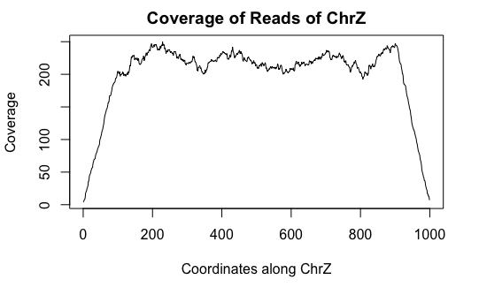

```r
# and we can plot it
plot(coverage(reads)$chrZ, ty="l", main="Coverage of Reads of ChrZ", xlab="Coordinates along ChrZ", ylab="Coverage")
```

Note the relatively stable coverage along the length of chrZ. This appears to indicate that there is no deletion along chrZ. Now let us look at another dataset reads_2 that came from a separate individual:

```r
# can you figure out what was done differently here?
starts = c(floor(runif(1000)*300), floor(runif(1000)*400)+500)+1
reads_2 = GRanges(seqname="chrZ", ranges=IRanges(start=starts, end = starts+99))
reduce(reads_2)
```

```
GRanges object with 2 ranges and 0 metadata columns:
      seqnames    ranges strand
         <Rle> <IRanges>  <Rle>
  [1]     chrZ     1-399      *
  [2]     chrZ   501-999      *
  -------
  seqinfo: 1 sequence from an unspecified genome; no seqlengths
```

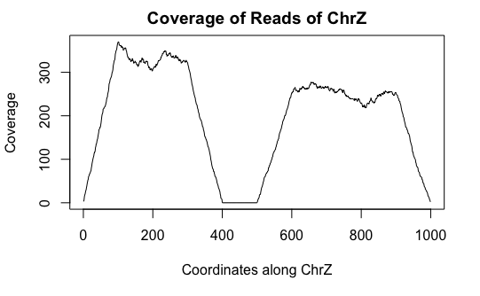

```r
# now let's plot the coverage again
plot(coverage(reads_2)$chrZ, ty="l", main="Coverage of Reads of ChrZ", xlab="Coordinates along ChrZ", ylab="Coverage")
```

Note the area of low to no coverage in the plot and the gap in sequence from `reduce` – this seems to indicate that a segment of chrZ is deleted in the second subject between bases 400 and 500. Now we wish to find **if this deletion overlaps any annotated regions in the reference genome**. This can be achieved using `findOverlaps` and a `GRanges` object containing the annotation information. There are many such annotations that have been created that can be loaded into R. For our example we can use the following annotation `GRanges` object annotation:

```r
annotation <- GRanges(seqnames="chrZ",
                      ranges = IRanges(start = c(100,200,400,700),
                                       end = c(150,250,550,750)),
                      strand = "*",
                      Gene_id = paste("Gene",1:4,sep = "_") )
annotation
```

```
GRanges object with 4 ranges and 1 metadata column:
      seqnames    ranges strand |     Gene_id
         <Rle> <IRanges>  <Rle> | <character>
  [1]     chrZ   100-150      * |      Gene_1
  [2]     chrZ   200-250      * |      Gene_2
  [3]     chrZ   400-550      * |      Gene_3
  [4]     chrZ   700-750      * |      Gene_4
  -------
  seqinfo: 1 sequence from an unspecified genome; no seqlengths
```

```r
ol = findOverlaps(GRanges(seqnames="chrZ", ranges=IRanges(start=500, end=600)), annotation)
annotation[subjectHits(ol)]
```

```
GRanges object with 1 range and 1 metadata column:
      seqnames    ranges strand |     Gene_id
         <Rle> <IRanges>  <Rle> | <character>
  [1]     chrZ   400-550      * |      Gene_3
  -------
  seqinfo: 1 sequence from an unspecified genome; no seqlengths
```

Thus, it would appear that Gene_3 is deleted in the second subject – this information can be passed on to downstream lab scientists for verification as well as general cataloging.

## Other resources

I looked at several tutorials and found all of them to be useful but only if you have a biological question in mind. So, they are more like your resource list, in case you need them. Here they are: use them as you see fit:

- [An Introduction to the GenomicRanges Package](https://bioconductor.org/packages/release/bioc/vignettes/GenomicRanges/inst/doc/GenomicRangesIntroduction.html#introduction) This is the tutorial on the official Bioconductor page for the `GenomicRanges` package
- [Getting started with the plyranges package](https://www.bioconductor.org/packages/release/bioc/vignettes/plyranges/inst/doc/an-introduction.html) This is built on `GenomicRanges` to enable `dplyr`-like grammar (the `%>%` pipes and `mutate()`, `group_by()` verbs etc.)
- [Counting reads with `summarizeOverlaps`](http://bioconductor.org/packages/release/bioc/vignettes/GenomicAlignments/inst/doc/summarizeOverlaps.pdf) This is a tutorial specifically aimed at counting reads overlapping certain ranges, e.g. counting transcripts in RNAseq.

Below are some of the first steps for the `plyranges` tutorial. I didn’t finish it as the remaining parts seem quite usage-specific. Feel free to use the above websites to browse on your own.

### `plyranges`

#### 1. Ranges, revisited

Here we use the `plyranges` package, which builds upon the `IRanges` and `GenomicRanges` packages by adding a `dplyr`-like interface, which makes it much easier to read and write code.

Something I found quite useful from the tutorial above, which I quote verbatim below

> `Ranges` objects can either represent sets of integers as `IRanges` (which have start, end and width attributes) or represent genomic intervals (which have additional attributes, sequence name, and strand) as `GRanges`. In addition, both types of `Ranges` can store information about their intervals as metadata columns (for example GC content over a genomic interval).

> `Ranges` objects follow the tidy data principle: each row of a `Ranges` object corresponds to an interval, while each column will represent a variable about that interval, and generally each object will represent a single unit of observation (like gene annotations).

> Consequently, `Ranges` objects provide a powerful representation for reasoning about genomic data. In this vignette, you will learn more about `Ranges` objects and how via grouping, restriction and summarisation you can perform common data tasks.

```r
# install and import the `plyranges` package, which depends on `tidyverse`, `iranges` and `genomicranges`
if (!requireNamespace("BiocManager", quietly = TRUE))
    install.packages("BiocManager")

suppressPackageStartupMessages(BiocManager::install("plyranges"))
suppressPackageStartupMessages(library(plyranges))
```

#### 2. Constructing `Ranges`

```r
set.seed(100)
df <- data.frame(start=c(2:-1, 13:15),
                 width=c(0:3, 2:0))
# produces IRanges
rng <- df %>% as_iranges()
rng
```

```
IRanges object with 7 ranges and 0 metadata columns:
          start       end     width
      <integer> <integer> <integer>
  [1]         2         1         0
  [2]         1         1         1
  [3]         0         1         2
  [4]        -1         1         3
  [5]        13        14         2
  [6]        14        14         1
  [7]        15        14         0
```

A GRanges object is an extension of an IRanges object. For each `range`, there is an associated “sequence name”, and an optional column to represent the strandedness of an interval. In addition, each genomic range can have one or more associated metadata, such as coverage, GC content etc.

To construct a `GRanges`, we use the `dplyr` (part of `tidyverse`) pipeline to add the additional `seqnames` and `strand` columns.

```r
# seqname is required for GRanges, metadata is automatically kept
# the `sample(LIST, NUM, replace = TRUE)` function performs sampling from "LIST" num of times with replacement
# the `runif(N)` function generates N pseudo-random numbers from a uniform distribution [0,1]
grng <- df %>%
  transform(seqnames = sample(c("chr1", "chr2"), 7, replace = TRUE),
         strand = sample(c("+", "-"), 7, replace = TRUE),
         gc = runif(7)) %>%
  as_granges() # this is the constructor function that is similar to as_iranges()

grng
```

```
GRanges object with 7 ranges and 1 metadata column:
      seqnames    ranges strand |                gc
         <Rle> <IRanges>  <Rle> |         <numeric>
  [1]     chr2       2-1      - |  0.76255108229816
  [2]     chr1         1      - | 0.669021712383255
  [3]     chr2       0-1      + | 0.204612161964178
  [4]     chr2      -1-1      - | 0.357524853432551
  [5]     chr1     13-14      - | 0.359475114848465
  [6]     chr1        14      - | 0.690290528349578
  [7]     chr2     15-14      - | 0.535811153938994
  -------
  seqinfo: 2 sequences from an unspecified genome; no seqlengths
```